# Red wine Analysis by Saurabh Sarkar

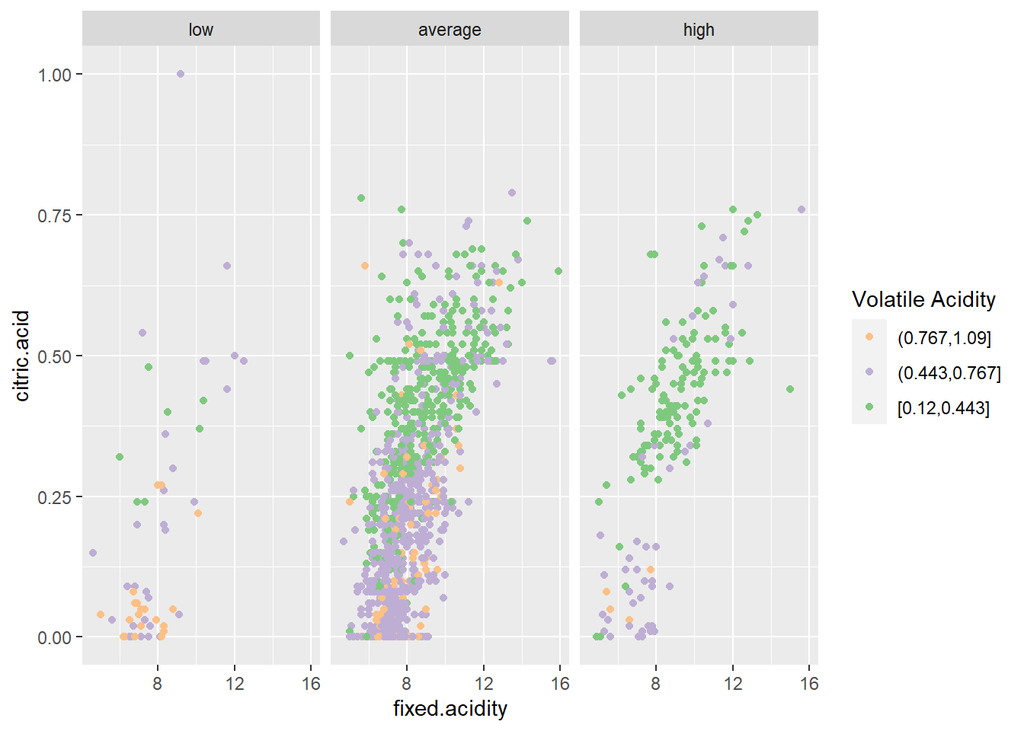

**Using *alcohol* buckets**: low level alcohol buckets ‘8.4 - 10.1’ (in green) is almost non-existent for ‘high’ quality wine

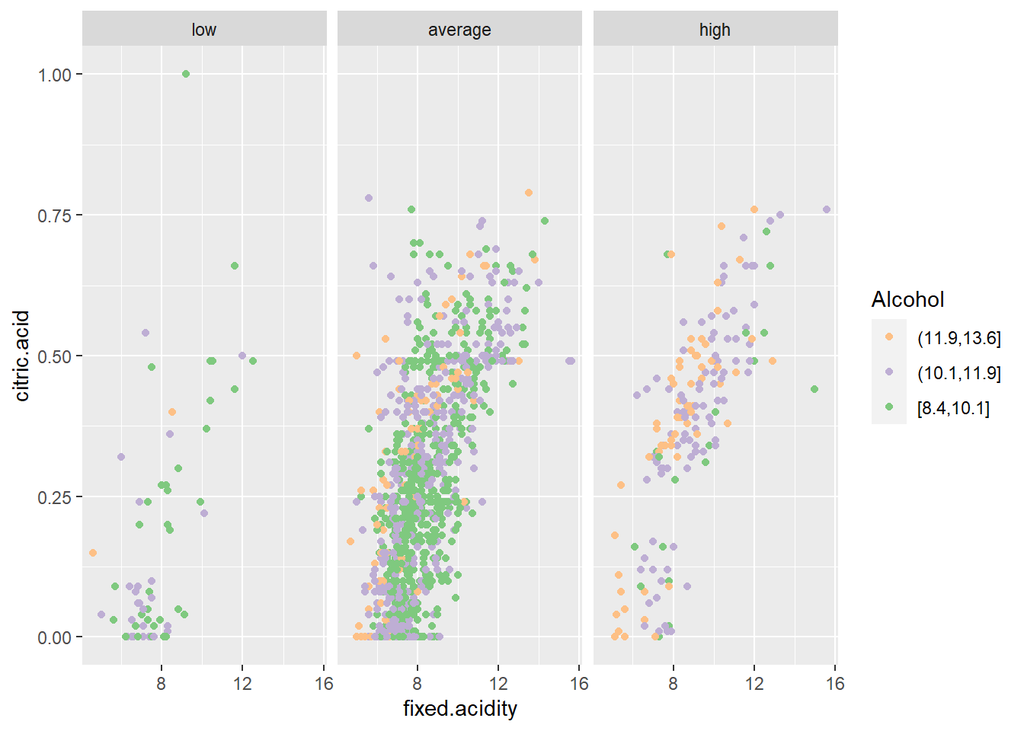

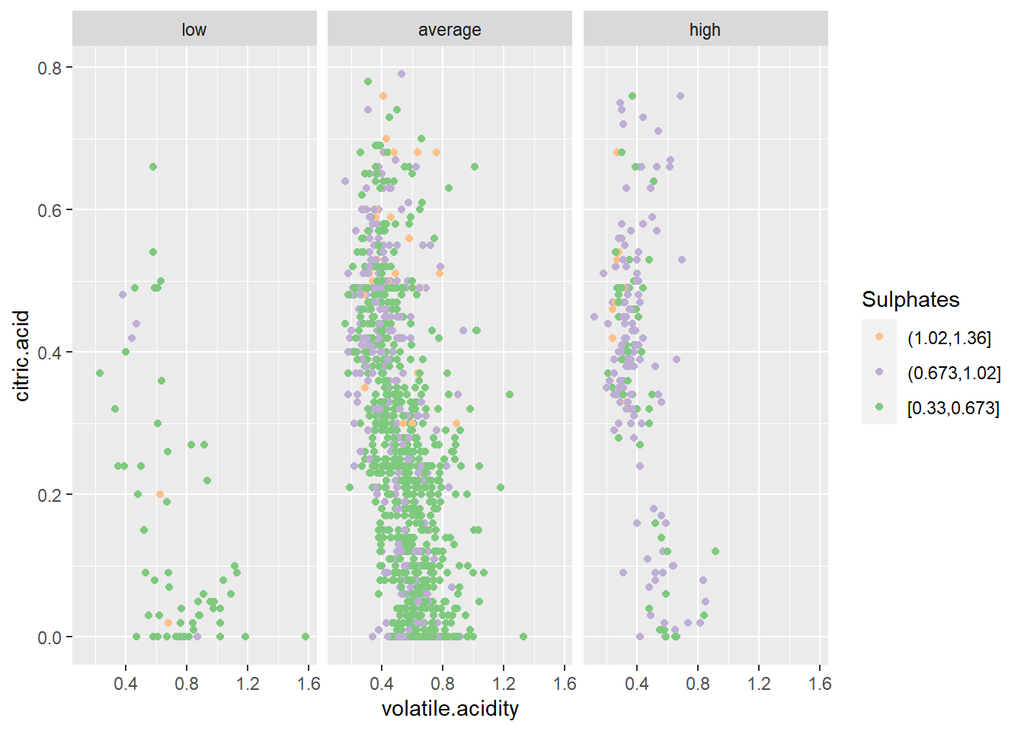

**Another plot using the *sulphates* bucket**: While the lower bucket influence is not confirmed in this plot, it is clear that that mid level ‘sulphate’ bucket has a clear influcene on ‘high’ quality wine

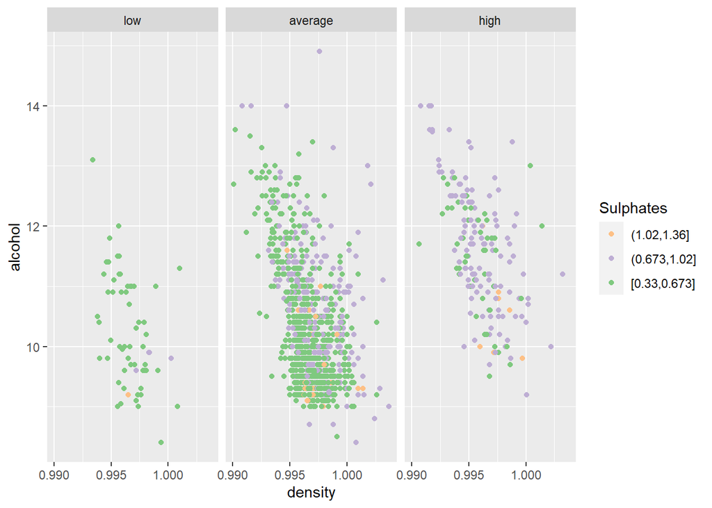

### Multivariate Analysis - Summary

**Features of Interest**: There is some distinction that differentiates the three levels of *alcohol*. It should be noted that there isn’t much data for the two extremes of the quality spectrum (high and low). Wine quality improves with increasing *citric.acid* levels. ‘Mid’ level and ‘High’ level *citric.acid* are prominent among the ‘Average’ and ‘High’ quality wines. Wine quality improves while reducing *volatile.acidity* levels. The mid range level for *volatile.acidity* (0.443-0.767) is very prominent among the ‘Average level wines, while *volatile.acidity* at LOW levels (0.12-0.443) constitutes for ’High’ wine quality. Wine quality improves while increasing *alcohol* levels. The highest range on *alcohol* levels (11.9-13.6) is quite prominent among the ‘High’ quality wines while almost non-existent among the ‘Low’ quality wines

# Summary of all Analysis

### Plot One

The bi-variate plots for *fixed acidity*, *volatile acidity*, *citric acid*, *sulphates* indicate an influence on the *quality*.

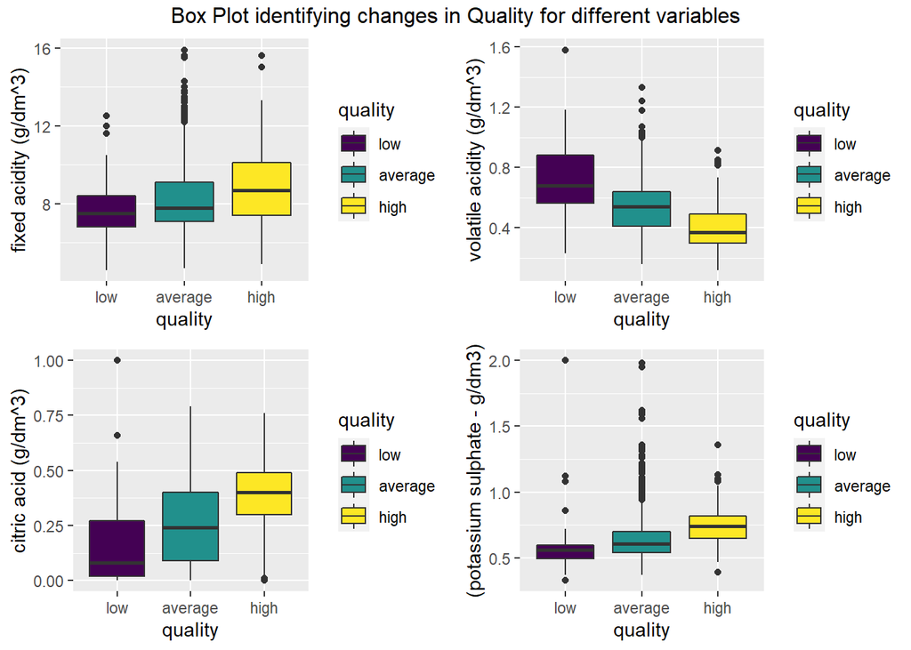

### Plot Two

Distinguishing the bivariate plot for *alcohol* as the high distribution of *alcohol’ volume has a clear distinction in ‘High’ quality wines, while ‘Average’ and ‘Low’ quality wines do not have much of a distinction in alcohol volume.

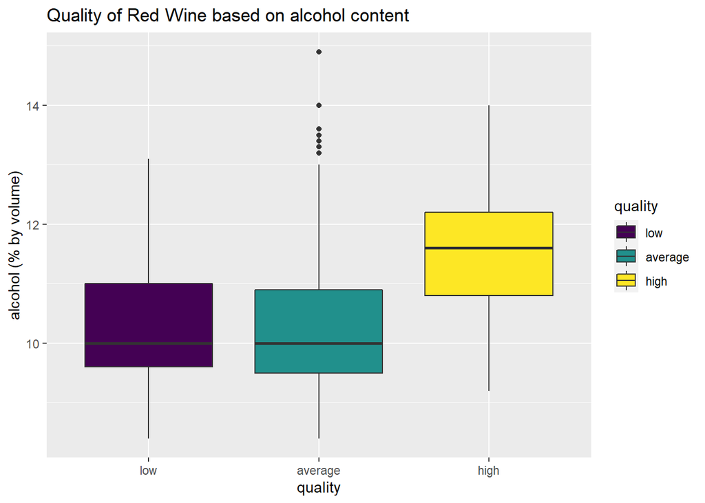

### Plot Three

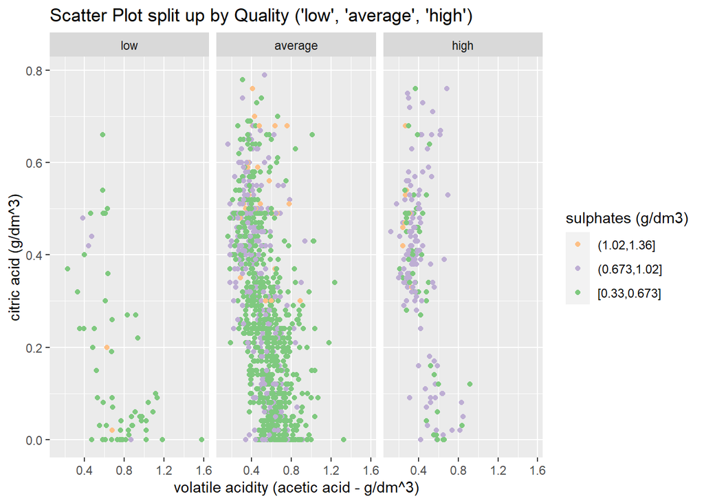

# Reflection

This dataset for red wine consists of only 1599 observations. The majority of the collected data fell in the the mid *quality* range (5 or 6) leaving very little data for the two extremes (low quality and high quality). This proved to be difficult to find definite proof of a strong correlation. Variables that influenced correlations were apparent from bi-variate analysis. Multivariate analysis was difficult due to every other variable other than quality is continuous. Even with forming discrete variables by forming buckets, a clear indication on the influence was not certain due to the very small numbers for ‘high’ and ‘low’ quality wine.

A relative approach comparing the influences of different variables on the different types of wine would probably prove to be more fruitful, like determining factors that effect red wine and white wine differently. The analysis here is the useful first step to gain insight into how to approach that analysis.